```css
/* This is css, which formats the html using whatever styles you wish.*/

@import "http://fonts.googleapis.com/css?family=Anonymous+Pro:400,400italic,700,700italic&subset=latin,latin-ext";
@import url(http://fonts.googleapis.com/css?family=Inconsolata:400,700);
@import url(http://fonts.googleapis.com/css?family=Source+Code+Pro:400,700);


body {
    margin:0 auto;
    font-family: "Times New Roman", Times, serif;
    font-size:1em;
    text-align:left;
    max-width:6.5in;
    line-height: 1.25em;
}

table {
    border-collapse: collapse;
    border-bottom:1px solid #000;
    margin:auto;
}

th, td{padding:5px;}



p {
  text-align:left;
    text-indent: 2em;
    padding: 0;
    margin:0;
}

li p {
  text-indent:0em;
  }

.references p {padding-left: 2.5em ;
    text-indent: -2.5em;}

.level1 h1 {font-size:1em;}

.level2 h2 {font-size:1em;}

.level3 h3 {font-size:1em;}

.level4
 h4 {font-size:1em;}

h1 {
    text-align:center;
}

h2, h3, h4, h5 {
text-align: left;
}

h3, h4, h5 {
margin-left: 2em;
}

.author , .date, .author_afil h4 {text-align:left;
        margin-left:0;
        font-weight:normal;
        font-style:normal;
        padding:0px;
        margin:0px;
        }

#header h4 em  {
        font-weight:normal;
        font-style:normal;
        }



blockquote p {text-indent:0em;
            margin-left:2.5em;}

blockquote p + p {
text-indent: 2.5em;
}

pre, img {
max-width: 100%;
}

pre {
overflow-x: auto;
}

code {
    font-family:"Anonymous Pro",monospace;
    text-align:left;
    padding:5px;
    font-size: 92%;
    border: 1px solid #ccc;
}

pre code {
font-size: 0.9em;
font-family: 'Source Code Pro' !important;
text-align: left;
display: block; padding: 0.5em;
}

code.r {
font-family: 'Inconsolata' !important;
font-size: 1.2em;
background-color: rgba(160, 160, 160, 0.2);
}
sup,sub {
    position: relative;
    vertical-align: 0;
}

sup {
    bottom: .4em
}

sub {
    top:.4em
}

.header th {
    border-bottom:1px solid #000;
    border-top: 1px solid #000;
    font-weight: normal;
}
```

**Note**: In order to compile the RMarkdown document, download [this RMarkdown document](http://my.ilstu.edu/~wjschne/442/IntroductiontoRMarkdown.Rmd), along with following files:

- APA.docx This file is a template to create MS Word documents in APA Style. The template is a work in progress and thus does not get everything exactly right.
- apa.csl This file tells RMarkdown how to format citations in APA Style.
- citations.bib This file contains a few citations in BibTeX format.

Be sure to save them in the same folder.

# RMarkdown

[Markdown](http://daringfireball.net/projects/markdown/basics) is a really simple way to format documents. [RMarkdown](http://rmarkdown.rstudio.com/) is a variant of Markdown that works in [RStudio](http://www.rstudio.com/).

With RMarkdown, you can do some really neat things. Like [this](http://my.ilstu.edu/~wjschne/RESCAE.html).

# Headers

```
# This is a Level 1 header
```

# This is a Level 1 header

```
## This is a Level 2 header
```

```
### Guess which level header this is!
```

### Guess which level header this is!

```
This is a regular paragraph. Extra       spaces between words are eliminated.
Even though this
sentence is broken
across many lines,
it is
grouped with the text
above it.
```

This is a regular paragraph. Extra spaces between words are eliminated. Even though this sentence is broken across many lines, it is grouped with the text above it.

```
Put an empty line between paragraphs.

You can't see them but if you put 2 or more spaces
at the end
of a line,
there is a line break.
```

Put an empty line between paragraphs.

You can’t see them but if you put 2 or more spaces  
at the end  
of a line,  
there is a line break.

# Formatting text

```
*This is italicized.*
```

*This is italicized.*

```
**This is bolded.**
```

**This is bolded.**

```
~~Strikethrough~~
```

Strikethrough

```
Superscript^2^
```

Superscript<sup>2</sup>

```
Subscript~2~
```

Subscript<sub>2</sub>

```
>This is for blockquotes.
>It can go on for
>many
>lines.
>
>This is the second paragraph in a blockquote.
In my .css file, I have formatted it so that it will be indented.
```

> This is for blockquotes. It can go on for many lines.

> This is the second paragraph in a blockquote. In my .css code, I have formatted it so that it will be indented.

````
Text enclosed in three backquotes (```) will
appear in a monospace type.
It is especially good for displaying computer code.
It will appear exactly
as
   you
       type it,
without the typical formatting.

For example,
*normally this would be italicized.*
````

# Lists

Let’s make an unordered list:

```
* First bullet point
* Second bullet point
    - Indented bullet point (2 tabs or 4 spaces)
    - Another indented bullet point
        + Further indentation (4 tabs or 8 spaces)
```

- First bullet point
- Second bullet point
  - Indented bullet point (2 tabs or 4 spaces)
  - Another indented bullet point
    - Further indentation (4 tabs or 8 spaces)

Let’s make an ordered list:

```
1. My first topic
    1. Sub topic 1
    2. Sub topic 2
2. My second topic
    * Subtopic (2 tabs or 4 spaces)
    * Another subtopic
    This is a indented paragraph in the middle of a list (2 tabs or 4 spaces).
    * Yet another subtopic
3. My third topic
```

1. My first topic
   1. Sub topic 1
   2. Sub topic 2
2. My second topic
   - Subtopic (2 tabs or 4 spaces)
   - Another subtopic  
     This is a indented paragraph in the middle of a list (2 tabs or 4 spaces).
   - Yet another subtopic
3. My third topic

# Links

```
[This is a link to my homepage.](http://my.ilstu.edu/~wjschne/)
```

[This is a link to my homepage.](http://my.ilstu.edu/~wjschne/)

# Images

```
![Ryan, Joel, and Jane](http://my.ilstu.edu/~wjschne/RyanJoelJane.jpg)
```

[figure not shown]

Ryan, Joel, and Jane

# Equations using LaTeX

```
$$f(X)=\frac{1}{\sigma\sqrt{2\pi}}e^{-\frac{1}{2}\left(\frac{X-\mu}{\sigma}\right)^2}$$
```

```
Left        |Center         |Right
:-----------|:-------------:|------------:
1           |2              |3
4           |5              |6
7           |8              |9
```

| Left | Center | Right |
| --- | --- | --- |
| 1 | 2 | 3 |
| 4 | 5 | 6 |
| 7 | 8 | 9 |

# Combining R and Markdown

## R code chunks

This code will run and will appear in the document:

```r
EvenNumbersUnder100 <- seq(2,98,2)
```

This code chunk will run but it will not appear in the document:

This code chunk will appear in the document but it will not run:

```r
Y<-tan(pi/4)
```

## Inline R code

```
You can refer to calculations in your text.
For example, the cosine of $\pi$ radians is -1.
In fact, you can refer to any R object
(e.g., the mean and standard deviation of a variable.)
```

You can refer to calculations in your text. For example, the cosine of $\pi$ radians is -1. In fact, you can refer to any R object (e.g., the mean and standard deviation of a variable.)

## Let’s make a simple plot with R:

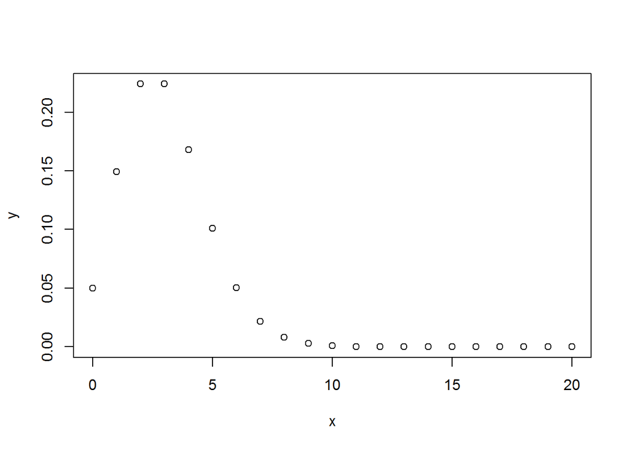

```r
# Sequence of integers from 0 to 20
x <- 0:20
# The probability mass function of the Poisson distribution
y <- dpois(x, lambda = 3)
# Plot the distribution
plot(y ~ x)
```

## Let’s make the plot ready for publication:

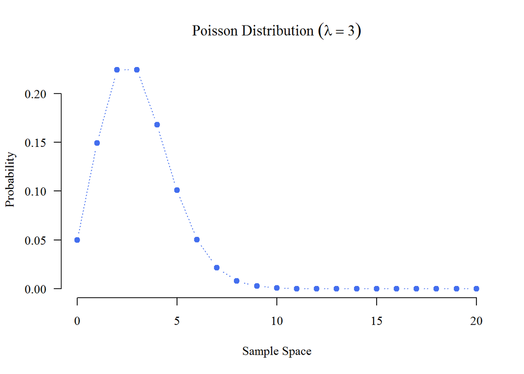

```r
plot(y ~ x,
     main = expression("Poisson Distribution " * (lambda == 3)), # Title
     xlab = "Sample Space", # x-axis label
     ylab = "Probability", # y-axis label
     type = "b", # plot both lines and points
     bty = "n", # No box around plot
     lty = 3, # Dotted lines
     col = "royalblue2", # Color of lines and points
     pch = 19, # Points are filled circles
     las = 1, # All labels are horizontal
     family = "serif") # Font family
```

## APA Formatted tables!

```r
# Sample size
n <- 1000
# Normal variate
g <- rnorm(n)
# Correlated variates
s1 <- g + rnorm(n)
s2 <- g + rnorm(n)
# Create data frame
d <- data.frame(g,s1,s2)
# Correlation matrix
dcor <- cor(d)
# Format to 2 digits
dcor <- formatC(dcor, digits = 2, format = "f")
# Remove lower triangle
dcor[lower.tri(dcor, diag = TRUE)] <- ""
# Remove leading zeroes
dcor <- gsub("0.",".",dcor)
# Remove last row and first column
dcor <- dcor[nrow(dcor)*-1,-1]
# Make table with centered columns
knitr::kable(dcor, align = "c", digits = 2)
```

|  | s1 | s2 |
| --- | --- | --- |
| g | .71 | .73 |
| s1 |  | .49 |

That seems like a lot of work to get a little table. I could have cut and paste those numbers into a table in MS Word much faster! However, many correlation matrices are large and require quite a bit of attention to get them into APA format.

If you drop the above code into a custom function and modify it slightly, you have a very useful function for creating correlation tables in APA format.

```r
CorTable <- function(d,caption = "Correlation Matrix", digits = 2, align = "c", ...){
# Correlation matrix
dcor <- cor(d)
# Format to 2 digits
dcor <- formatC(dcor, digits = 2, format = "f")
# Remove lower triangle
dcor[lower.tri(dcor, diag = TRUE)] <- ""
# Remove leading zeroes
dcor <- gsub("0.",".",dcor)
# Remove last row and first column
dcor <- dcor[nrow(dcor)*-1,-1]
# Make table with centered columns
knitr::kable(dcor, caption = caption, digits = digits, align = align, ...)
}
```

Let’s load a data set with 10 variables:

```r
x10 <- readr::read_csv("http://my.ilstu.edu/~wjschne/444/x10.csv")
```

Now you can create large correlation tables with just one line of code.

```r
CorTable(x10)
```

Correlation Matrix

|  | x2 | x3 | x4 | x5 | x6 | x7 | x8 | x9 | x10 |
| --- | --- | --- | --- | --- | --- | --- | --- | --- | --- |
| x1 | .70 | .73 | .73 | .67 | .76 | .76 | .66 | .71 | .76 |
| x2 |  | .71 | .74 | .72 | .71 | .75 | .65 | .68 | .77 |
| x3 |  |  | .69 | .66 | .66 | .68 | .70 | .64 | .78 |
| x4 |  |  |  | .68 | .69 | .65 | .69 | .68 | .76 |
| x5 |  |  |  |  | .71 | .74 | .73 | .64 | .78 |
| x6 |  |  |  |  |  | .72 | .70 | .67 | .76 |
| x7 |  |  |  |  |  |  | .72 | .68 | .75 |
| x8 |  |  |  |  |  |  |  | .68 | .76 |
| x9 |  |  |  |  |  |  |  |  | .75 |

For now, there is no expectation that you should be able to create a function like this. The point is that RMarkdown is a powerful tool that can make you much more productive than people who cut and paste all their analyses into the write-up.

# Citations

As explained [here](http://rmarkdown.rstudio.com/authoring_bibliographies_and_citations.html), if you use the bibliography tag, you can insert citations with the @ symbol and the citation’s unique ID. A variety of citation file formats are supported and a huge number of citation styles are [available](https://zotero.org/styles). I am using the [BibTeX file format](http://www.bibtex.org/) with the [APA (6<sup>th</sup> Edition) citation style](https://zotero.org/styles/apa).